# Car insurance model

Jérémy Gamanga

I study the claim frequency and the claim severity of private motor insurance. The dataset comprises 183,999 observations of automobile insurance policy losses over a one-year period in Norway. I am gonna apply different GLM and select the best one.

Male ->1 if the policyholder is a male, 0 otherwise. \ Young ->1 if the policyholder age is below 26 years, 0 otherwise. \

DistLimit -> The distance limit as stated in the insurance contract:“8000 km”, “12000 km”, “16000 km”, “20000 km”,“25000-30000 km”, “no limit”. \

GeoRegion -> Density of the geographical region (from heaviest to lightest): “High+”, “High-”,“Medium+”,“Medium-”,“Low+”, “Low-”. \

Expo -> Exposure as a fraction of year. \ ClaimAmount -> 0 or the average claim amount if NbClaim > 0. \

NbClaim -> The claim number. \

## Load data

```r
norauto <- read.csv("norwegianclaim.csv", stringsAsFactors = TRUE)
ordlevel <- c(paste0("Low", c("-","+")),
              paste0("Medium", c("-","+")),
              paste0("High", c("-","+")))

norauto$GeoRegion <- factor(norauto$GeoRegion, rev(ordlevel))
ordlevel <- c("8000 km", "12000 km","16000 km","20000 km",
              "25000-30000 km","no limit")

norauto$DistLimit <- factor(norauto$DistLimit, rev(ordlevel))
```

```r
summary(norauto)
```

```
##       Male           Young                 DistLimit       GeoRegion
##  Min.   :0.000   Min.   :0.0000   no limit      :53689   High+  :44212
##  1st Qu.:1.000   1st Qu.:0.0000   25000-30000 km:30763   High-  :55308
##  Median :1.000   Median :0.0000   20000 km      :37007   Medium+:41493
##  Mean   :0.976   Mean   :0.2431   16000 km      :12969   Medium-:25925
##  3rd Qu.:1.000   3rd Qu.:0.0000   12000 km      :34307   Low+   :14135
##  Max.   :1.000   Max.   :1.0000   8000 km       :15264   Low-   : 2926
##       Expo          ClaimAmount        NbClaim
##  Min.   : 0.1010   Min.   :     0   Min.   :0.00000
##  1st Qu.: 0.3100   1st Qu.:     0   1st Qu.:0.00000
##  Median : 0.5750   Median :     0   Median :0.00000
##  Mean   : 0.6622   Mean   :  1082   Mean   :0.04767
##  3rd Qu.: 1.0000   3rd Qu.:     0   3rd Qu.:0.00000
##  Max.   :25.8490   Max.   :700000   Max.   :3.00000
```

```r
cor(norauto[,-(3:4)]) # remove non-numerical variables
```

```
##                      Male        Young         Expo  ClaimAmount      NbClaim
## Male         1.0000000000 0.0001646511 0.0379106823 -0.011680134 -0.013720478
## Young        0.0001646511 1.0000000000 0.0001516988  0.004743203  0.008125141
## Expo         0.0379106823 0.0001516988 1.0000000000  0.090979330  0.154563232
## ClaimAmount -0.0116801340 0.0047432035 0.0909793302  1.000000000  0.611475321
## NbClaim     -0.0137204779 0.0081251412 0.1545632323  0.611475321  1.000000000
```

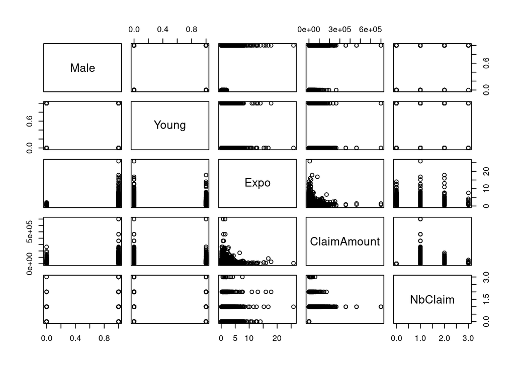

```r
pairs(norauto[,-(3:4)])
```

## Deal with exposure term

To find a good way to deal with exposure, we consider independent Poisson random variables P(ei λ) where λ is the unknown parameter and ei is the known exposure length of ith observation.

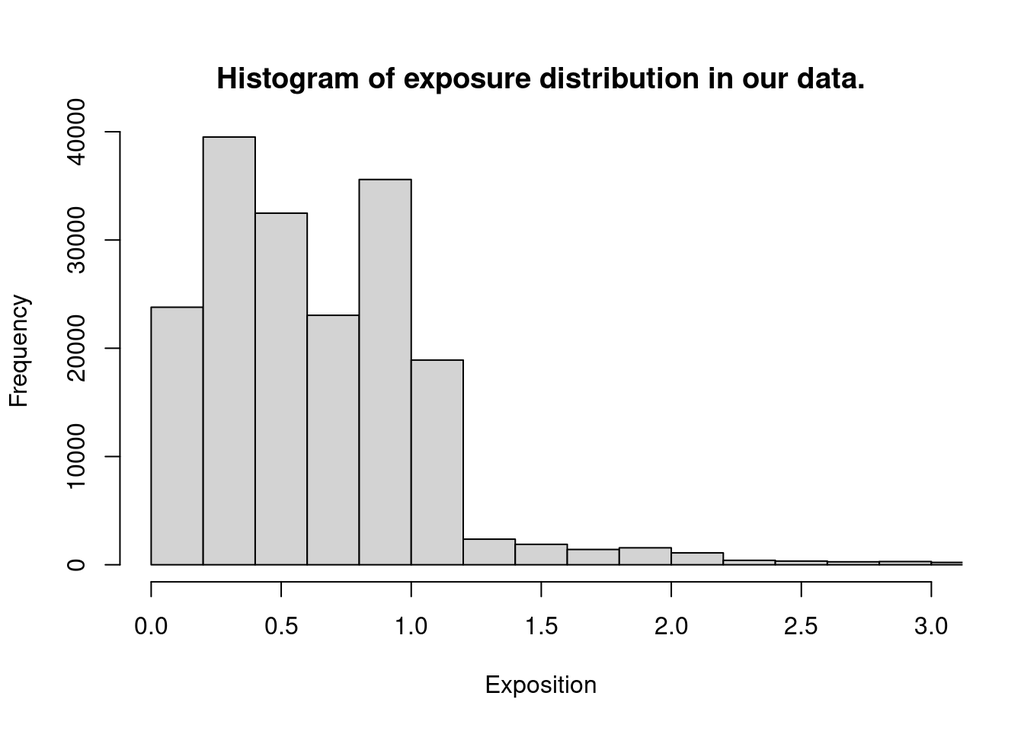

```r
hist(norauto$Expo, xlim=c(0,3), n=100, main="
Histogram of exposure distribution in our data.", xlab="Exposition" , ylab="Frequency")
```

We can see that many of the data have exposure durations of less than $1$. This means that the data collected for these observations was gathered over a period shorter than one year. If we don’t take this into account, we run the risk of underestimating the number of accidents.

We then test three ways of integrating this information into our regression.

```r
n <- 500
ei <- runif(n, 1/2, 1)
ni <- rpois(n, lambda=1 * ei) #printout with true lambda value


f0<- glm(ni ~ 1, family = poisson("log")) # We don't include it in regression
f1 <- glm(ni ~ 1, weights=ei, family = poisson("log")) # This is done by weighting
f2 <- glm(ni ~ 1 + offset(log(ei)), family = poisson("log")) # we do this by imposing the ordinate at the origin


c(exp(coef(f0)), exp(coef(f1)), exp(coef(f2))) #lambda
```

```
## (Intercept) (Intercept) (Intercept)
##   0.7820000   0.8163655   1.0462229
```

we can see that f2 gives the right value because we’ve imposed the y-intercept. This is information we already have, so it’s natural to impose it, otherwise the model will try to estimate it, resulting in a loss of accuracy.

We can see that f1 and f0 give a lower estimate than the real value. Let’s see if there’s a negative bias. Let’s vary $ambda$.

```r
library("latex2exp")

coeff_f0 <- c()
coeff_f1 <- c()
coeff_f2 <- c()
lamnda_max <- 50

for (i in 1:lamnda_max)
{

  ni <- rpois(n, lambda=i * ei)
  f0 <- glm(ni ~ 1, family = poisson("log")) # We don't include it in regression
  f1 <- glm(ni ~ 1, weights=ei, family = poisson("log")) # This is done by weighting
  f2 <- glm(ni ~ 1 + offset(log(ei)), family = poisson("log")) # we do this by imposing the ordinate at the origin

  print(exp(coef(f0)))
  coeff_f0 <- append(coeff_f0, (exp(coef(f0))-i))
  coeff_f1 <- append(coeff_f1, (exp(coef(f1))-i))
  coeff_f2 <- append(coeff_f2, (exp(coef(f2))-i))
}
```

```
## (Intercept)
##       0.698
## (Intercept)
##       1.392
## (Intercept)
##       2.306
## (Intercept)
##       3.204
## (Intercept)
##       3.836
## (Intercept)
##       4.568
## (Intercept)
##       5.206
## (Intercept)
##       6.036
## (Intercept)
##       6.772
## (Intercept)
##       7.798
## (Intercept)
##       8.182
## (Intercept)
##       9.058
## (Intercept)
##       9.766
## (Intercept)
##      10.278
## (Intercept)
##      11.398
## (Intercept)
##       12.02
## (Intercept)
##       12.46
## (Intercept)
##      13.238
## (Intercept)
##      13.926
## (Intercept)
##      15.218
```

[output cut: 45 more lines]

```
##      31.966
## (Intercept)
##      33.178
## (Intercept)
##      33.454
## (Intercept)
##      34.758
## (Intercept)
##      35.218
## (Intercept)
##       36.03
## (Intercept)
##      36.716
## (Intercept)
##      37.304
```

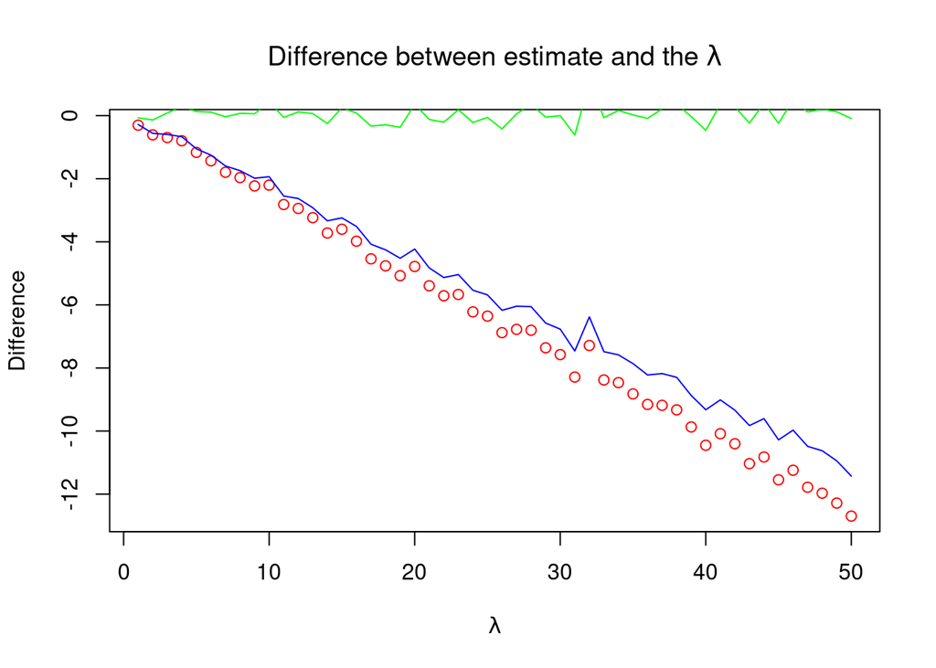

```r
x <- seq(1,lamnda_max,1)
plot(x, coeff_f0, col="red", main = TeX(r'(Difference between estimate and the $\lambda$)'), ylab="Difference", xlab=TeX(r'($\lambda$)'))
lines(x, coeff_f1, col="blue")
lines(x, coeff_f2,col="green")
```

We can see that the estimated value is always smaller than the actual value. Each time, f1 and f0 underestimate the value of $lambda$. What’s more, the absolute difference between the predicted value and the true value increases as the value of $\lambda$ increases.

The exposure can go above 1. Let’s see if this impacts the prediction.

```r
coeff_f0 <- c()
coeff_f1 <- c()
coeff_f2 <- c()
lamnda_max <- 50
ei <- runif(n, 1/2, 3)

for (i in 1:lamnda_max)
{

  ni <- rpois(n, lambda=i * ei)
  f0 <- glm(ni ~ 1, family = poisson("log")) # We don't include it in the regression
  f1 <- glm(ni ~ 1, weights=ei, family = poisson("log")) # This is done by weighting
  f2 <- glm(ni ~ 1 + offset(log(ei)), family = poisson("log")) # we do this by imposing the ordinate at the origin

  print(exp(coef(f0)))
  coeff_f0 <- append(coeff_f0, (exp(coef(f0))-i))
  coeff_f1 <- append(coeff_f1, (exp(coef(f1))-i))
  coeff_f2 <- append(coeff_f2, (exp(coef(f2))-i))
}
```

```
## (Intercept)
##       1.854
## (Intercept)
##        3.65
## (Intercept)
##       5.434
## (Intercept)
##       7.242
## (Intercept)
##       9.126
## (Intercept)
##        10.8
## (Intercept)
##      12.232
## (Intercept)
##      14.514
## (Intercept)
##      16.344
## (Intercept)
##       18.42
## (Intercept)
##      20.194
## (Intercept)
##      21.796
## (Intercept)
##      23.402
## (Intercept)
##      25.114
## (Intercept)
##      27.106
## (Intercept)
##      28.926
## (Intercept)
##          31
## (Intercept)
##       32.73
## (Intercept)
##      34.684
## (Intercept)
##      36.464
```

[output cut: 45 more lines]

```
##      78.048
## (Intercept)
##      79.968
## (Intercept)
##       81.63
## (Intercept)
##      82.908
## (Intercept)
##      85.252
## (Intercept)
##      87.404
## (Intercept)
##      89.062
## (Intercept)
##      90.246
```

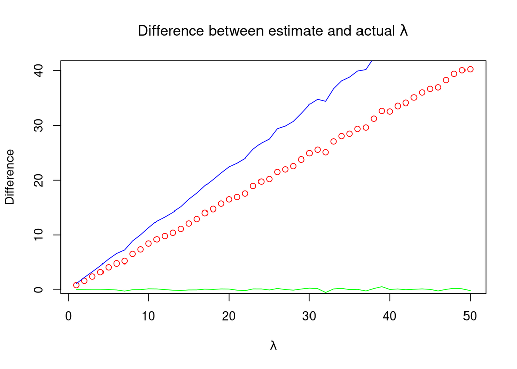

```r
x <- seq(1,lamnda_max,1)
plot(x, coeff_f0, col="red", main = TeX(r'(Difference between estimate and actual $\lambda$)'), ylab="Difference", xlab=TeX(r'($\lambda$)'))
lines(x, coeff_f1, col="blue")
lines(x, coeff_f2,col="green")
```

This time, f1 and f0 overestimate $\lambda$. The error is always greater the larger $\lambda$ is.

## GLM Poisson

```r
pois <- glm(NbClaim ~ Male + Young + DistLimit + GeoRegion  + offset(log(Expo)), data=norauto , family = poisson("log"))

pois <-step(pois, direction="back")
```

```
## Start:  AIC=66778.79
## NbClaim ~ Male + Young + DistLimit + GeoRegion + offset(log(Expo))
##
##             Df Deviance   AIC
## <none>            49667 66779
## - Young      1    49679 66789
## - Male       1    49738 66848
## - GeoRegion  5    49801 66903
## - DistLimit  5    50270 67371
```

```r
exp(coef(pois))
```

```
##             (Intercept)                    Male                   Young
##               0.1909485               0.5812966               1.0905216
## DistLimit25000-30000 km       DistLimit20000 km       DistLimit16000 km
##               0.8325863               0.7278613               0.5971564
##       DistLimit12000 km        DistLimit8000 km          GeoRegionHigh-
##               0.5332660               0.4609800               0.8263083
##        GeoRegionMedium+        GeoRegionMedium-           GeoRegionLow+
##               0.7916220               0.7485136               0.6708861
##           GeoRegionLow-
##               0.5897336
```

```r
summary(pois)
```

```
##
## Call:
## glm(formula = NbClaim ~ Male + Young + DistLimit + GeoRegion +
##     offset(log(Expo)), family = poisson("log"), data = norauto)
##
## Deviance Residuals:
##     Min       1Q   Median       3Q      Max
## -1.4085  -0.3508  -0.2700  -0.1906   4.3169
##
## Coefficients:
##                         Estimate Std. Error z value Pr(>|z|)
## (Intercept)             -1.65575    0.06295 -26.303  < 2e-16 ***
## Male                    -0.54249    0.05921  -9.163  < 2e-16 ***
## Young                    0.08666    0.02461   3.521  0.00043 ***
## DistLimit25000-30000 km -0.18322    0.03107  -5.897 3.69e-09 ***
## DistLimit20000 km       -0.31764    0.03019 -10.522  < 2e-16 ***
## DistLimit16000 km       -0.51558    0.04648 -11.093  < 2e-16 ***
## DistLimit12000 km       -0.62873    0.03365 -18.683  < 2e-16 ***
## DistLimit8000 km        -0.77440    0.04615 -16.780  < 2e-16 ***
## GeoRegionHigh-          -0.19079    0.02765  -6.900 5.21e-12 ***
## GeoRegionMedium+        -0.23367    0.03059  -7.640 2.17e-14 ***
## GeoRegionMedium-        -0.28967    0.03669  -7.895 2.90e-15 ***
## GeoRegionLow+           -0.39916    0.04878  -8.183 2.77e-16 ***
## GeoRegionLow-           -0.52808    0.10680  -4.945 7.62e-07 ***
## ---
## Signif. codes:  0 '***' 0.001 '**' 0.01 '*' 0.05 '.' 0.1 ' ' 1
##
## (Dispersion parameter for poisson family taken to be 1)
##
##     Null deviance: 50453  on 183998  degrees of freedom
## Residual deviance: 49667  on 183986  degrees of freedom
## AIC: 66779
##
## Number of Fisher Scoring iterations: 6
```

All p-values are low. Thus, there is no explanatory variable to remove with the Poisson model.

We can see that the main factors reducing the number of accidents are being in a very sparsely populated region, being male and having a contract coverage of 8000km to 16000km.

Being young is weakly but positively correlated with a higher number of accidents.

```r
tapply(norauto$NbClaim, norauto$DistLimit, mean )
```

```
##       no limit 25000-30000 km       20000 km       16000 km       12000 km
##     0.06148373     0.04911745     0.04472127     0.04163775     0.03535722
##        8000 km
##     0.03616352
```

## Preduction

```r
df1 <- data.frame(Male=1, Young=1, DistLimit="no limit", GeoRegion="Low-", Expo=1)
predict(pois, newdata = df1, type="response", prec=1)
```

```
##          1
## 0.07138455
```

Thus, the prediction suggests that, on average, a young man without borderline distance, living in low-density areas makes approximately 0.07 claims in a year.

## GLM gamma

```r
norsub <- subset(norauto, NbClaim > 0)
dim(norsub)
```

```
## [1] 8444    7
```

```r
Gamm <- glm(ClaimAmount ~ DistLimit + GeoRegion + Male + Young , data=norsub , family = Gamma("log"))
summary(Gamm)
```

```
##
## Call:
## glm(formula = ClaimAmount ~ DistLimit + GeoRegion + Male + Young,
##     family = Gamma("log"), data = norsub)
##
## Deviance Residuals:
##     Min       1Q   Median       3Q      Max
## -4.2812  -0.8665  -0.3498   0.1538   6.9416
##
## Coefficients:
##                           Estimate Std. Error t value Pr(>|t|)
## (Intercept)             10.1323674  0.0779956 129.909   <2e-16 ***
## DistLimit25000-30000 km  0.0319108  0.0384573   0.830   0.4067
## DistLimit20000 km        0.0951263  0.0373079   2.550   0.0108 *
## DistLimit16000 km        0.0451843  0.0574896   0.786   0.4319
## DistLimit12000 km        0.0484038  0.0413905   1.169   0.2423
## DistLimit8000 km         0.0388317  0.0569956   0.681   0.4957
## GeoRegionHigh-          -0.0159301  0.0342473  -0.465   0.6418
## GeoRegionMedium+         0.0082319  0.0379040   0.217   0.8281
## GeoRegionMedium-        -0.0008611  0.0452301  -0.019   0.9848
## GeoRegionLow+            0.0149729  0.0601435   0.249   0.8034
## GeoRegionLow-           -0.2300499  0.1325196  -1.736   0.0826 .
## Male                    -0.0986417  0.0730904  -1.350   0.1772
## Young                   -0.0019167  0.0305402  -0.063   0.9500
## ---
## Signif. codes:  0 '***' 0.001 '**' 0.01 '*' 0.05 '.' 0.1 ' ' 1
##
## (Dispersion parameter for Gamma family taken to be 1.469817)
##
##     Null deviance: 8508.0  on 8443  degrees of freedom
## Residual deviance: 8490.6  on 8431  degrees of freedom
## AIC: 186943
##
## Number of Fisher Scoring iterations: 6
```

With a model taking all variables into account, we find that all p-values, with the exception of those for DistLimit20000km and GeoRegionLow- , are greater than 0.1. Thus, the corresponding explanatory variables are not appropriate for this model.

So the relevant explanatory variables in the generalized linear model, with the explanatory variables following a gamma distribution, are DistLimit20000km and GeoRegionLow-.

We can see that the low density of the geographical area has more influence than the distance of the contract coverage.

Let’s use the $step$ command to select the most relevant explanatory variables.

```r
Gamm_stepped <- step(Gamm, direction="back")
```

```
## Start:  AIC=186942.7
## ClaimAmount ~ DistLimit + GeoRegion + Male + Young
##
##             Df Deviance    AIC
## - GeoRegion  5   8495.6 186936
## - DistLimit  5   8500.6 186939
## - Young      1   8490.6 186941
## - Male       1   8493.4 186943
## <none>           8490.6 186943
##
## Step:  AIC=186938.4
## ClaimAmount ~ DistLimit + Male + Young
##
##             Df Deviance    AIC
## - DistLimit  5   8505.5 186935
## - Young      1   8495.6 186936
## - Male       1   8498.1 186938
## <none>           8495.6 186938
##
## Step:  AIC=186939.8
## ClaimAmount ~ Male + Young
```

```r
summary(Gamm_stepped)
```

```
##
## Call:
## glm(formula = ClaimAmount ~ Male + Young, family = Gamma("log"),
##     data = norsub)
##
## Deviance Residuals:
##     Min       1Q   Median       3Q      Max
## -4.2796  -0.8703  -0.3312   0.1543   7.1259
##
## Coefficients:
##              Estimate Std. Error t value Pr(>|t|)
## (Intercept) 10.157573   0.072686 139.747   <2e-16 ***
## Male        -0.092680   0.073515  -1.261    0.207
## Young        0.001295   0.030397   0.043    0.966
## ---
## Signif. codes:  0 '***' 0.001 '**' 0.01 '*' 0.05 '.' 0.1 ' ' 1
##
## (Dispersion parameter for Gamma family taken to be 1.493303)
##
##     Null deviance: 8508.0  on 8443  degrees of freedom
## Residual deviance: 8505.5  on 8441  degrees of freedom
## AIC: 186940
##
## Number of Fisher Scoring iterations: 5
```

We then find that the most relevant model takes into account the explanatory variables indicating gender and age group. We can therefore see that the gamma distribution model is not appropriate, as the p-values are very high, above 0.2. We can therefore have no confidence in these estimates.

Furthermore, if we compare the AIC of this model ($186940$) with that of the Poisson model ($66779$), we see that its AIC is much greater. Our Poisson model is therefore of better quality.

## GLM inverse

Inverse law

```r
ig1 <- glm(ClaimAmount ~ Male + Young + DistLimit + GeoRegion , data=norsub , family = inverse.gaussian("log"), start=coef(Gamm), control=list(maxit=100))

summary(ig1)
```

```
##
## Call:
## glm(formula = ClaimAmount ~ Male + Young + DistLimit + GeoRegion,
##     family = inverse.gaussian("log"), data = norsub, start = coef(Gamm),
##     control = list(maxit = 100))
##
## Deviance Residuals:
##      Min        1Q    Median        3Q       Max
## -0.99996  -0.00687  -0.00238   0.00098   0.03277
##
## Coefficients:
##                           Estimate Std. Error t value Pr(>|t|)
## (Intercept)             10.1324204  0.0806024 125.709   <2e-16 ***
## Male                    -0.0976217  0.0759579  -1.285   0.1988
## Young                   -0.0011375  0.0304665  -0.037   0.9702
## DistLimit25000-30000 km  0.0301038  0.0380785   0.791   0.4292
## DistLimit20000 km        0.0941506  0.0377212   2.496   0.0126 *
## DistLimit16000 km        0.0453292  0.0574650   0.789   0.4302
## DistLimit12000 km        0.0463612  0.0412480   1.124   0.2611
## DistLimit8000 km         0.0382849  0.0567867   0.674   0.5002
## GeoRegionHigh-          -0.0159587  0.0341172  -0.468   0.6400
## GeoRegionMedium+         0.0062290  0.0379312   0.164   0.8696
## GeoRegionMedium-         0.0001012  0.0452006   0.002   0.9982
## GeoRegionLow+            0.0135398  0.0603402   0.224   0.8225
## GeoRegionLow-           -0.2337065  0.1184040  -1.974   0.0484 *
## ---
## Signif. codes:  0 '***' 0.001 '**' 0.01 '*' 0.05 '.' 0.1 ' ' 1
##
## (Dispersion parameter for inverse.gaussian family taken to be 6.204233e-05)
##
##     Null deviance: 19.903  on 8443  degrees of freedom
## Residual deviance: 19.902  on 8431  degrees of freedom
## AIC: 215195
##
## Number of Fisher Scoring iterations: 4
```

GeoRegionLow- and DistLimit20000km are still the model’s two main explanatory variables. This is a poor model, with an AIC of $215195, which is higher than that of the model under the Gamma distribution. This model is therefore of poorer quality than the model under the Gamma distribution and therefore than the model under the Poisson distribution.

## Model Selection:

The model with the lowest AIC is the Poisson model. Let’s compare the pseudo $R²$ of each model, which should give us the same result:

With a Poisson noise distribution.